# Ratemaking Capstone

Robert Riesenberg

9/26/2020

## Overview

Creating a frequency-severity analysis for a pure premium analysis by limit.

## Exploratory Data Analysis

Briefly looking over the data beforehand.

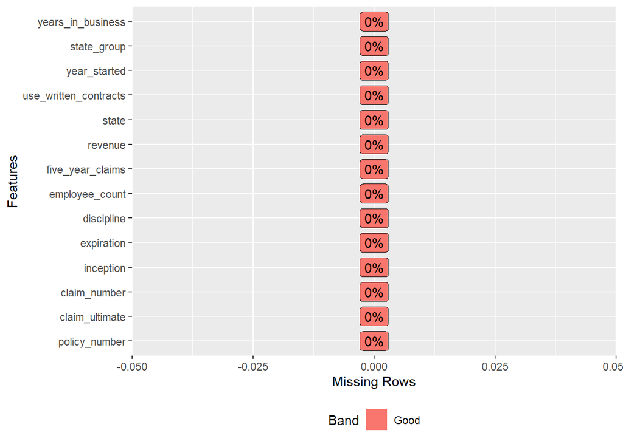

```r
## Checking to see if there are any missing values
claims_final %>%
  plot_missing()
```

There are no missing values in the policy or claim dataset so the data is extremely clean.

Looking over the distribution of the variables.

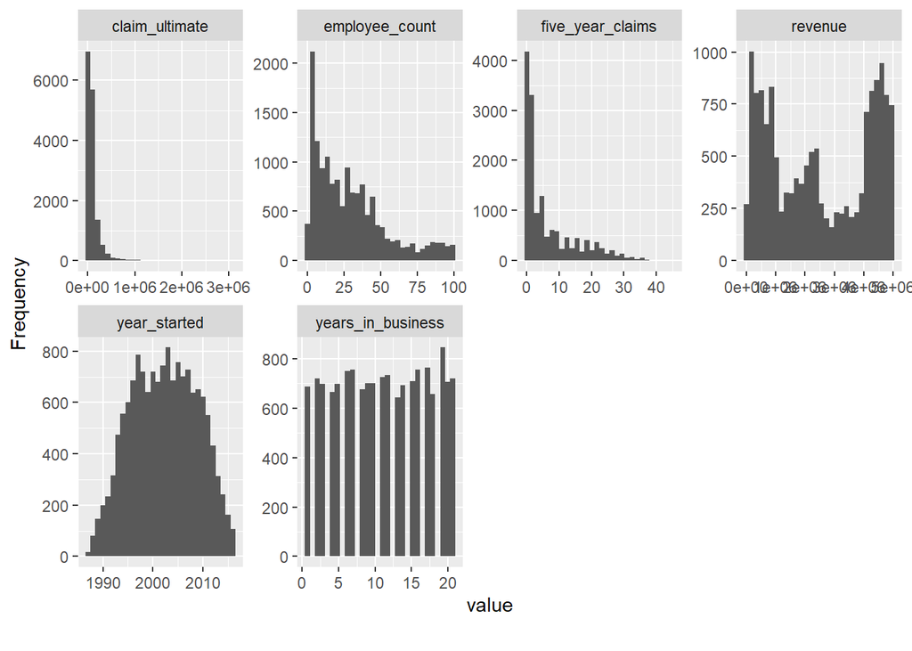

```r
claims_final %>%
  select(-c(inception ,expiration)) %>%
  plot_histogram()
```

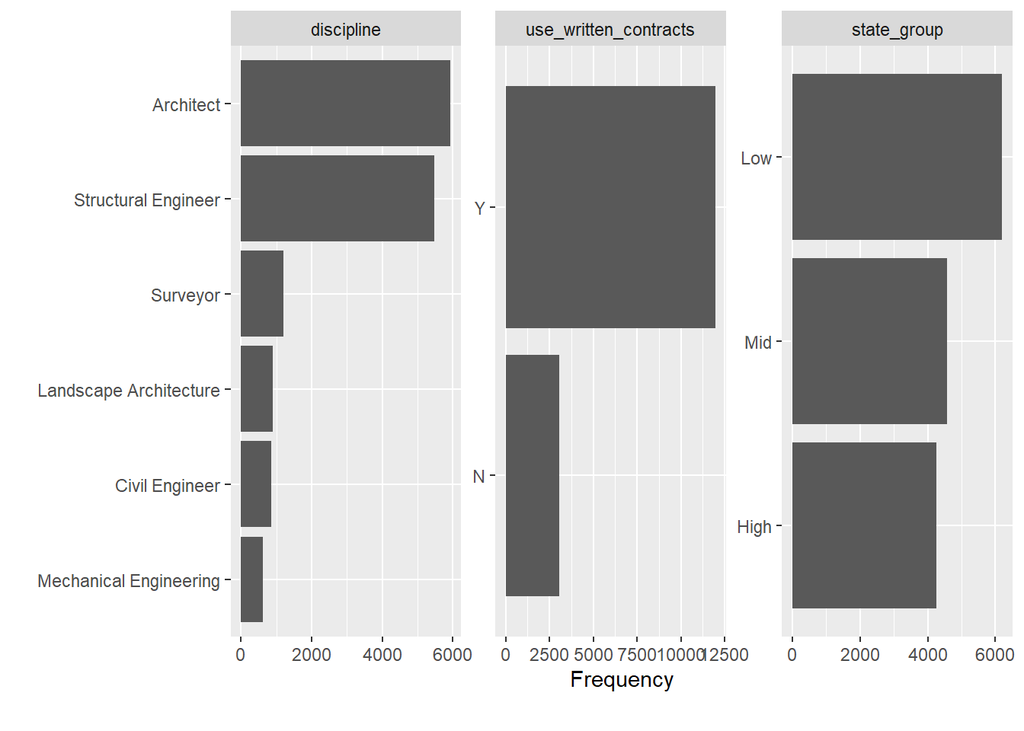

```r
claims_final %>%
  plot_bar()
```

After seeing how the variables are distributed, want to check the correlations b/w variables.

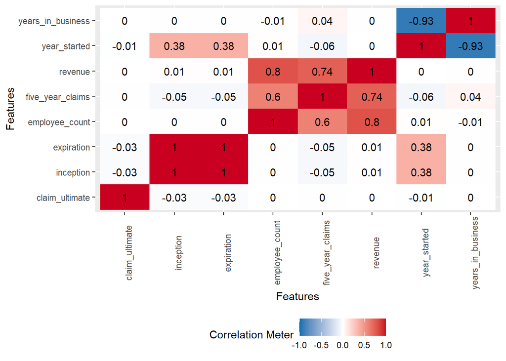

```r
claims_final %>%
  plot_correlation(type = 'continuous')
```

## Severity Distribution

Want to fit a distribution to the claims ultimate severity data. Will be testing Gamma, Lognormal & Weibull.

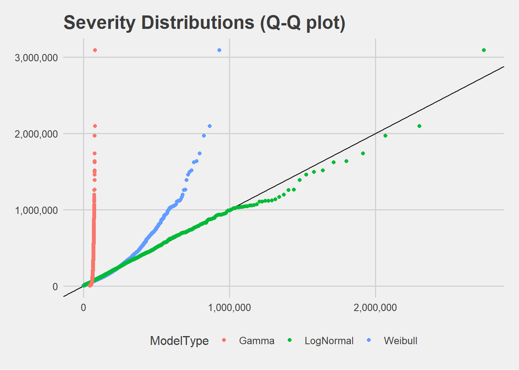

```r
fitGamma <- fitdistr(claims_final$claim_ultimate ,dgamma ,list(shape = 1.126754, rate = .01) ,lower = .0025)
fitLognormal <- fitdistr(claims_final$claim_ultimate ,"lognormal")
fitWeibull <- fitdistr(claims_final$claim_ultimate ,"Weibull")

## Probabilities ranging from 0 to 1
sims <- nrow(claims_final)
probabilities = seq_len(sims)/(sims + 1)

weibullQ <- qweibull(probabilities, coef(fitWeibull)[1], coef(fitWeibull)[2])
lnQ <- qlnorm(probabilities, coef(fitLognormal)[1], coef(fitLognormal)[2])
gammaQ <- qgamma(probabilities, coef(fitGamma)[1], coef(fitGamma)[2])

sortedSeverity <- sort(claims_final$claim_ultimate)

tibble(
  x          = c(sort(weibullQ) ,sort(lnQ) ,sort(gammaQ))
  ,y         = rep(sortedSeverity ,3)
  ,ModelType = c(rep("Weibull" ,length(sortedSeverity)) ,rep("LogNormal" ,length(sortedSeverity)) ,rep("Gamma" ,length(sortedSeverity)))
) %>%
  ggplot(aes(x ,y ,color = ModelType)) +
  geom_point() +
  geom_abline(intercept = 0 ,slope = 1) +
  scale_x_continuous(labels = scales::comma) +
  scale_y_continuous(labels = scales::comma) +
  geom_jitter() +
  theme_fivethirtyeight() +
  ggtitle("Severity Distributions (Q-Q plot)")
```

After determining that the Lognormal fit was best, compared the fitted Lognormal density to the actual density.

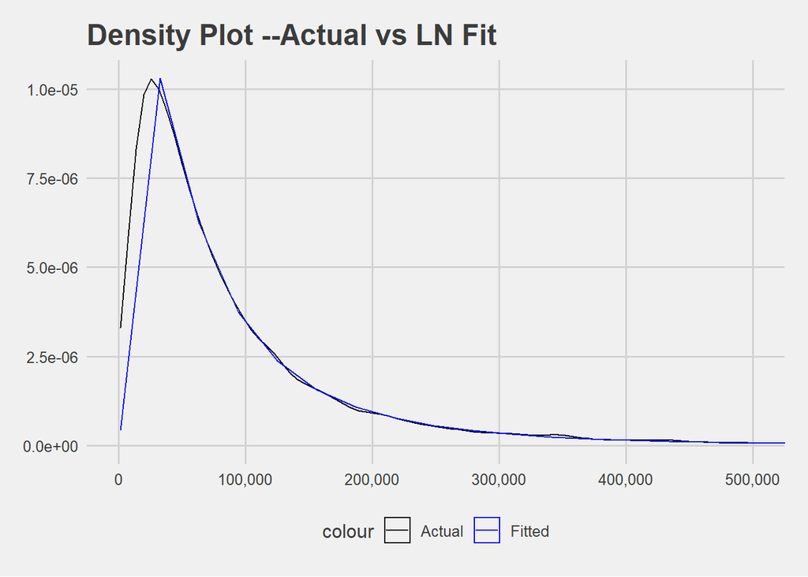

```r
sampleLogMean <- fitLognormal$estimate[1]
sampleLogSd <- fitLognormal$estimate[2]

tibble(
  x = sortedSeverity
) %>%
  ggplot(aes(x ,color = "Actual")) +
  geom_density() +
  coord_cartesian(xlim = c(0 ,500000)) +
  stat_function(fun = dlnorm ,args = list(meanlog = sampleLogMean ,sdlog = sampleLogSd) ,aes(color = "Fitted")) +
  scale_color_manual(values = c("black" ,"blue")) +
  scale_x_continuous(labels = scales::comma) +
  ggtitle("Density Plot --Actual vs LN Fit") +
  theme_fivethirtyeight()
```

Severity distribution is looking pretty good.

## Frequency GLM

Want to investigate to see if there are any add’l variables which should be added to the frequency GLM.

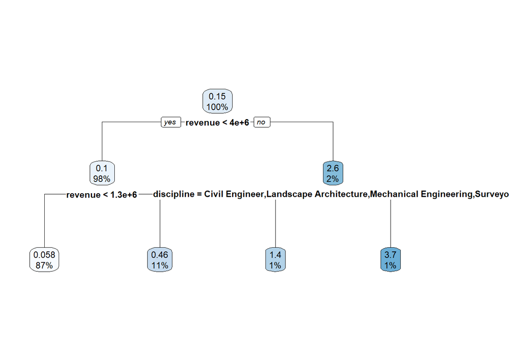

```r
## Adding add'l variables
pol_final <- pol_final %>%
  mutate(Frequency         = claim_count / revenue * 1000000
         ,RevenueGreater4m = if_else(revenue >= 4000000 ,1 ,0)
         ,EffectiveDate    = as.Date(str_c(str_sub(inception ,1 ,4) ,str_sub(inception ,-2 ,-1) ,"1" ,sep = "-"))
         ,ExpirationDate   = as.Date(str_c(str_sub(expiration ,1 ,4) ,str_sub(expiration ,-2 ,-1) ,"1" ,sep = "-"))
         ,EffectiveYear    = year(EffectiveDate)
         ,EffectiveMonth   = month(EffectiveDate)
         ,LengthInDays     = interval(EffectiveDate ,ExpirationDate) %/% days(1)
         )

pol_final_predictors_only <- pol_final %>%
  select(-c(policy_number ,inception ,expiration ,total_ultimate ,state ,average_severity ,Frequency)) %>%
  select(-c(contains("Effective") ,ExpirationDate ,LengthInDays))

tree_claim_count <- rpart(claim_count ~ . ,data = na.omit(pol_final_predictors_only) ,control = rpart.control(cp = .03))

rpart.plot(tree_claim_count)
```

Revenue being greater than $4M seems like it may be useful. Going to build models both with & without it in as an indicator to see if adding it is a good idea. Also will be checking frequency distributions & to see if adding an offset will increase performance.

```r
## Fitting various Poisson models
fit_poisson_no_rev_offset <- glm(formula = claim_count ~ . ,data = select(pol_final_predictors_only ,-RevenueGreater4m) ,family = "poisson" ,offset = log(revenue))
fit_poisson_rev_no_offset <- glm(formula = claim_count ~ . ,data = pol_final_predictors_only ,family = "poisson")
fit_poisson_rev_offset <- glm(formula = claim_count ~ . ,data = pol_final_predictors_only ,family = "poisson" ,offset = log(revenue))

## Fitting a negative binomial model
#### Offset not working with glm.nb function
#### Have to manually create the formula by adding in offset(log(revenue)) to formula
glm_nb_formula_with_offset <- pol_final_predictors_only %>%
  select(-claim_count) %>%
  colnames() %>%
  str_c(collapse = " + ") %>%
  str_replace(pattern = "revenue" ,replacement = "offset(log(revenue))")
nb_glm_formula <- as.formula(str_c("claim_count ~ " ,glm_nb_formula_with_offset))
nb_glm_formula_less_vars <- as.formula(str_remove_all(str_c("claim_count ~ " ,glm_nb_formula_with_offset) ,pattern = "\\+ employee_count |\\+ year_started |\\+ use_written_contracts |\\+ years_in_business |\\+ five_year_claims"))

fit_neg_bin_rev_offset <- glm.nb(formula = nb_glm_formula ,data = pol_final_predictors_only)
fit_neg_bin_rev_offset_less_vars <- glm.nb(formula = nb_glm_formula_less_vars ,data = pol_final_predictors_only)

model_results <- bind_rows(glance(fit_poisson_no_rev_offset) ,glance(fit_poisson_rev_no_offset) ,glance(fit_poisson_rev_offset) ,glance(fit_neg_bin_rev_offset) ,glance(fit_neg_bin_rev_offset_less_vars))

model_results %>%
  bind_cols(ModelType                  = c("Poisson" ,"Poisson" ,"Poisson" ,"Negative Binomial" ,"Negative Binomial")
            ,Offset                    = c("log(revenue)" ,"None" ,"log(revenue)" ,"log(revenue)" ,"log(revenue)")
            ,`Revenue >4M Flag`        = c("No" ,"Included" ,"Included" ,"Included" ,"Included")
            ,`Noise Variables Removed` = c("No" ,"No" ,"No" ,"No" ,"Yes")
            ) %>%
  select(ModelType ,`Revenue >4M Flag` ,Offset ,`Noise Variables Removed` ,AIC ,BIC ,logLik) %>%
  kable(digits = 0 ,format.args = list(big.mark = ',')) %>%
  kable_classic(full_width = F, html_font = "Cambria") %>%
  column_spec(5:7 ,color = "white" ,background = spec_color(model_results$AIC ,end = 0.7 ,direction = -1))
```

| ModelType | Revenue >4M Flag | Offset | Noise Variables Removed | AIC | BIC | logLik |
| --- | --- | --- | --- | --- | --- | --- |
| Poisson | No | log(revenue) | No | 62,937 | 63,071 | -31,455 |
| Poisson | Included | None | No | 64,908 | 65,051 | -32,439 |
| Poisson | Included | log(revenue) | No | 62,190 | 62,332 | -31,080 |
| Negative Binomial | Included | log(revenue) | No | 60,341 | 60,484 | -30,156 |
| Negative Binomial | Included | log(revenue) | Yes | 60,332 | 60,428 | -30,156 |

Having a Negative Binomial model with an offset for revenue, an indicator of whether revenue is greater than $4M, and removing less important variables seems to be the best model.

Need to look over the diagnostic plots.

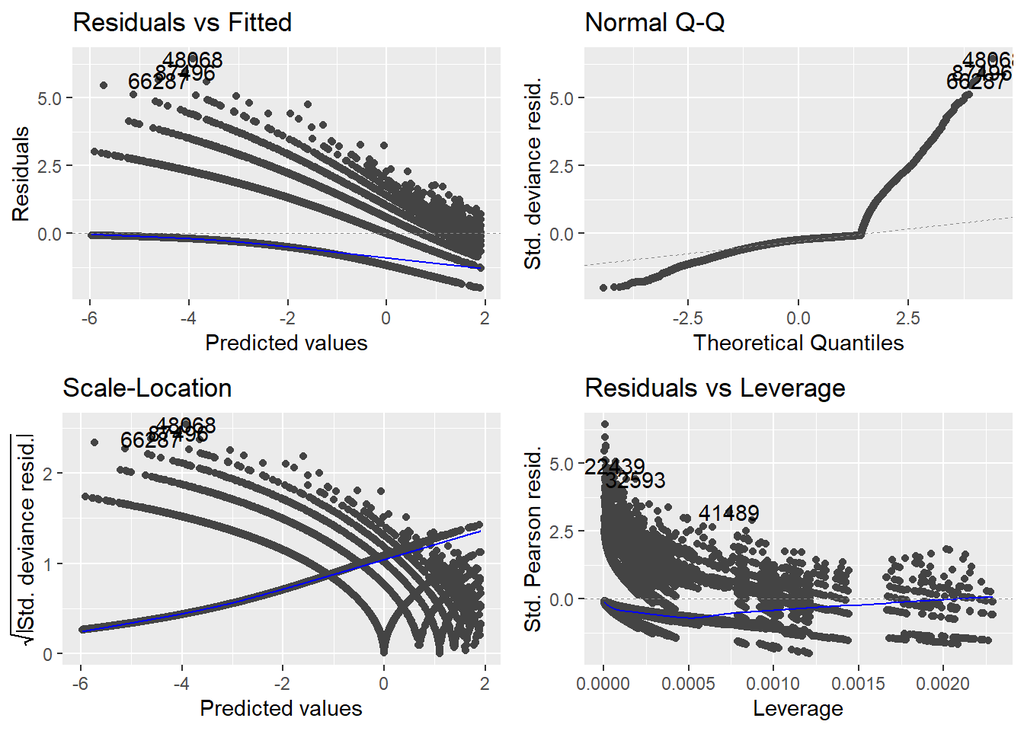

```r
autoplot(fit_neg_bin_rev_offset_less_vars)
```

These diagonostics will be investigated further.

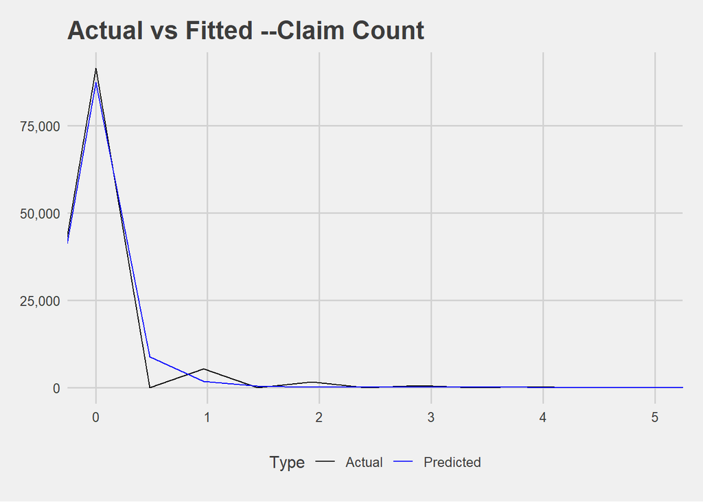

```r
pol_final_chart <- pol_final %>%
  mutate(predicted_claim_count = predict(fit_neg_bin_rev_offset_less_vars ,type = "response"))

tibble(
  x     = c(pol_final_chart$claim_count ,pol_final_chart$predicted_claim_count)
  ,Type = c(rep("Actual" ,nrow(pol_final_chart)) ,rep("Predicted" ,nrow(pol_final_chart)))
) %>%
  ggplot(aes(x ,color = Type)) +
  geom_freqpoly() +
  scale_y_continuous(labels = scales::comma) +
  coord_cartesian(xlim = c(0 ,5)) +
  scale_color_manual(values = c("black" ,"blue")) +
  ggtitle("Actual vs Fitted --Claim Count") +
  theme_fivethirtyeight()
```

Predictions seem to imitate the data reasonably well.

## Pure Premiums

Calculating pure premium values at the policy level and examining pure premiums with limits by discipline.

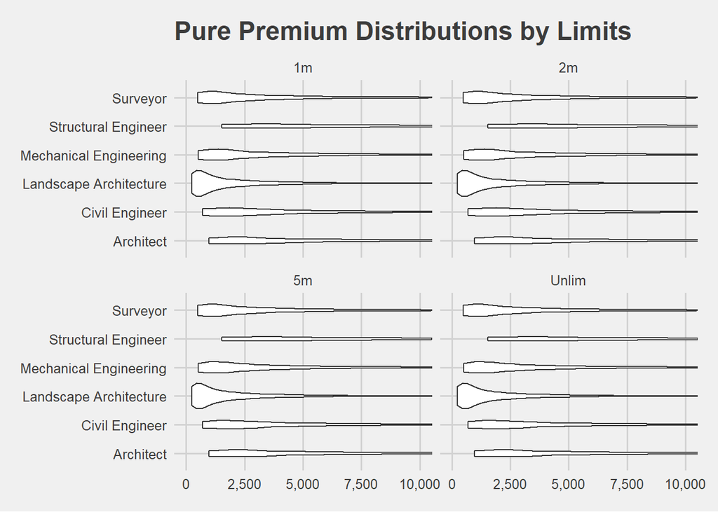

```r
Lev1m <- levlnorm(1e6 ,meanlog = sampleLogMean ,sdlog = sampleLogSd)
Lev2m <- levlnorm(2e6 ,meanlog = sampleLogMean ,sdlog = sampleLogSd)
Lev5m <- levlnorm(5e6 ,meanlog = sampleLogMean ,sdlog = sampleLogSd)
UnlimLev <- mlnorm(1 ,meanlog = sampleLogMean ,sdlog = sampleLogSd)

pol_final_with_levs <- pol_final %>%
  mutate(predicted_claim_count  = predict(fit_neg_bin_rev_offset_less_vars ,type = "response")
         ,PurePrem1m            = predicted_claim_count * Lev1m
         ,PurePrem2m            = predicted_claim_count * Lev2m
         ,PurePrem5m            = predicted_claim_count * Lev5m
         ,UnlimPurePrem         = predicted_claim_count * UnlimLev
        )

pol_final_with_levs %>%
  select(policy_number ,discipline ,contains("PurePrem")) %>%
  gather(key = "Limit" ,value = "PurePremium" ,-c(policy_number ,discipline)) %>%
  mutate(Limit = str_remove_all(Limit ,pattern = "PurePrem")) %>%
  ggplot(aes(x = PurePremium ,y = discipline)) +
  geom_violin() +
  facet_wrap(~ Limit) +
  coord_cartesian(xlim = c(0 ,1e4)) +
  scale_x_continuous(labels = scales::comma) +
  ggtitle("Pure Premium Distributions by Limits") +
  theme_fivethirtyeight()
```

Looking at the mean values.

```r
pol_final_with_levs %>%
  group_by(discipline) %>%
  summarise_at(vars(contains("PurePrem")) ,mean) %>%
  arrange(desc(UnlimPurePrem)) %>%
  kable(digits = 0 ,format.args = list(big.mark = ',')) %>%
  kable_classic(full_width = F, html_font = "Cambria")
```

| discipline | PurePrem1m | PurePrem2m | PurePrem5m | UnlimPurePrem |
| --- | --- | --- | --- | --- |
| Structural Engineer | 26,911 | 27,146 | 27,187 | 27,189 |
| Architect | 16,999 | 17,148 | 17,173 | 17,174 |
| Civil Engineer | 12,520 | 12,629 | 12,648 | 12,649 |
| Mechanical Engineering | 8,933 | 9,011 | 9,025 | 9,025 |
| Surveyor | 8,812 | 8,889 | 8,902 | 8,903 |
| Landscape Architecture | 4,315 | 4,353 | 4,359 | 4,359 |